# 5-Homework Using `dplyr` and `ggplot2`

Conducting a t-test to compare two independent groups.

You will need these libraries:

```r
library(ggplot2)
library(dplyr)
library(tidyr)
```

You will need this data:

```r
data(msleep)
```

**Question 1**. Use `dplyr` to recreate the summary table below using the `msleep` dataset (built into ggplot). You will need to use several of the `dplyr` verbs (functions) we have learned in class. Your full table should have 17 rows (although fewer rows may be displayed by default).

```
## # A tibble: 17 × 5
##    name                           order     brainwt  bodywt   ratio
##    <chr>                          <chr>       <dbl>   <dbl>   <dbl>
##  1 Jaguar                         Carnivora 0.157   100     0.00157
##  2 Gray seal                      Carnivora 0.325    85     0.00382
##  3 Dog                            Carnivora 0.07     14     0.005
##  4 Red fox                        Carnivora 0.0504    4.23  0.0119
##  5 Arctic fox                     Carnivora 0.0445    3.38  0.0132
##  6 Domestic cat                   Carnivora 0.0256    3.3   0.00776
##  7 Genet                          Carnivora 0.0175    2     0.00875
##  8 African giant pouched rat      Rodentia  0.0066    1     0.0066
##  9 Arctic ground squirrel         Rodentia  0.0057    0.92  0.00620
## 10 Guinea pig                     Rodentia  0.0055    0.728 0.00755
## 11 Chinchilla                     Rodentia  0.0064    0.42  0.0152
## 12 Laboratory rat                 Rodentia  0.0019    0.32  0.00594
## 13 Cotton rat                     Rodentia  0.00118   0.148 0.00797
## 14 Mole rat                       Rodentia  0.003     0.122 0.0246
## 15 Golden hamster                 Rodentia  0.001     0.12  0.00833
## 16 Thirteen-lined ground squirrel Rodentia  0.004     0.101 0.0396
## 17 House mouse                    Rodentia  0.0004    0.022 0.0182
```

**Question 2**. Use a t-test to compare the two mammal orders, Rodentia and Carnivora, in their ratio of brain weight to body weight. Format your answer as you would see in the results section of a scientific journal article.

**Question 3**. Using `ggplot2`, replicate the following figure. Fill in the values from your t-test (Question 2).

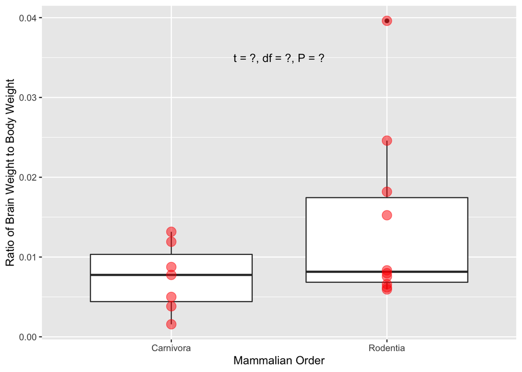

**Question 4**. Save the plot to your Rproject folder for this exercise as a 6” X 6” .jpg file.

Homework (folder containing .rproj file and all associated input/output files) is due to the D2L Assignments dropbox **before class one week from today**.  
As before, make each of your ‘answers’ an object. (e.g.) Answer_3 <- ggplot(data_summary, aes(x = …….. and ‘print’ the name of the object below the specified code (e.g. Answer_3). Each object is then displayed automatically in the console (if a model or table) or plot viewer (if its a graph) without having to click on anything.